# Riders

Salah Afaghani

2026-02-19

# Study Riders

## Introduction

Welcome to my Google Data Analytics Capstone project! In this case study, I am assuming the role of a Junior Data Analyst working on the marketing analyst team at **Cyclistic**, a fictional bike-share company based in Chicago.

### The Business Task

Cyclistic’s finance analysts have concluded that annual members are much more profitable than casual riders. The Director of Marketing believes the company’s future success depends on maximizing the number of annual memberships.

My team’s goal is to design a new marketing strategy to convert casual riders into annual members. To do that, we must first understand the behavioral differences between these two customer segments. The primary business question I am answering in this report is: **How do annual members and casual riders use Cyclistic bikes differently?**

### The Data Source

To answer this question, I am analyzing Cyclistic’s historical trip data. Specifically, I am focusing on a comparative analysis of the fourth quarter (October, November, December) across two years: 2024 and 2025.

*Note: The data used for this case study is public bicycle-sharing data from Divvy. The Divvy system is owned by the City of Chicago and operated by Lyft Bikes and Scooters, LLC. The data has been made available under a [public data license agreement](https://divvybikes.com/data-license-agreement) and can be downloaded directly from the [Divvy Data portal](https://divvy-tripdata.s3.amazonaws.com/index.html). All personally identifiable information has been removed to ensure rider privacy.*

## Install & Load libraries

```r
# install.packages("tidyverse")
# install.packages("skimr")
# install.packages("readr")
library(tidyverse)
library(skimr)
library(readr)
library(lubridate)
library(ggplot2)
library(scales)
```

## Read CSV files into variables

```r
riders_202410 <- read_csv("202410-divvy-tripdata.csv")
riders_202411 <- read_csv("202411-divvy-tripdata.csv")
riders_202412 <- read_csv("202412-divvy-tripdata.csv")
riders_202510 <- read_csv("202510-divvy-tripdata.csv")
riders_202511 <- read_csv("202511-divvy-tripdata.csv")
riders_202512 <- read_csv("202512-divvy-tripdata.csv")
```

## Cleaning Steps

Combine all data frames and do basics cleaning.

```r
data_list <- list(riders_202410, riders_202411, riders_202412, riders_202510, riders_202511, riders_202512)

# A container to store our cleaning stats
cleaning_summary <- data.frame()

process_and_track <- function(df, df_name) {
  # 0. Initial Count
  initial_count <- nrow(df)

  # 1. Typecasting and Strings (doesn't change row count)
  df_clean <- df %>%
    mutate(
      started_at = as.POSIXct(started_at),
      ended_at = as.POSIXct(ended_at),
      across(where(is.character), ~str_squish(str_trim(.))),
      ride_length = as.numeric(difftime(ended_at, started_at, units = "secs")),
      weekday = wday(started_at, label = TRUE, abbr = FALSE)
    )

  # 2. Track Business Logic Drops
  # We filter step-by-step to see exactly where data is lost
  too_short <- df_clean %>% filter(ride_length <= 60) %>% nrow()
  too_long  <- df_clean %>% filter(ride_length >= 86400) %>% nrow()
  no_move   <- df_clean %>% filter(start_lat == end_lat & start_lng == end_lng) %>% nrow()
  gps_error <- df_clean %>% filter(is.na(end_lat) | end_lat <= 40 | end_lat >= 45) %>% nrow()

  # 3. Apply the final filter
  df_final <- df_clean %>%
    filter(
      ride_length > 60,
      ride_length < 86400,
      start_lat != end_lat | start_lng != end_lng,
      !is.na(end_lat), # Handle NAs first to avoid filter issues
      end_lat > 40 & end_lat < 45,
      end_lng > -90 & end_lng < -80
    ) %>%
    mutate(
      start_station_name = replace_na(start_station_name, "On-Street / GPS Check-in"),
      end_station_name = replace_na(end_station_name, "On-Street / GPS Check-in")
    )

  # 4. Save results to the summary table
  stats <- data.frame(
    dataset = df_name,
    original = initial_count,
    lost_too_short = too_short,
    lost_too_long = too_long,
    lost_no_movement = no_move,
    lost_gps_outliers = gps_error,
    final = nrow(df_final)
  )

  # Use global assignment to update the summary table
  cleaning_summary <<- bind_rows(cleaning_summary, stats)

  return(df_final)
}

# Apply the tracker (assuming your dataframes are in a named list)
data_names <- c("2024_10", "2024_11", "2024_12", "2025_10", "2025_11", "2025_12")
cleaned_list <- map2(data_list, data_names, process_and_track)

# Final step: Duplicates (Tracked separately after merge)
all_rides_combined <- bind_rows(cleaned_list)
total_before_dup <- nrow(all_rides_combined)
all_rides_final <- all_rides_combined %>% distinct(ride_id, .keep_all = TRUE)
total_after_dup <- nrow(all_rides_final)

# View the cleaning report
print(cleaning_summary)
```

```
##   dataset original lost_too_short lost_too_long lost_no_movement
## 1 2024_10   616281          10798           594            32470
## 2 2024_11   335075           5414           274            14229
## 3 2024_12   178372           3347           141             7385
## 4 2025_10   646039          17016           599            36813
## 5 2025_11   356628           9549           337            20196
## 6 2025_12   140534           3962           125             7690
##   lost_gps_outliers  final
## 1               570 580234
## 2               273 318753
## 3               131 169336
## 4               586 604812
## 5               357 333984
## 6               122 131731
```

```r
cat("Rows lost to duplicates:", total_before_dup - total_after_dup)
```

```
## Rows lost to duplicates: 0
```

Then Order the weekday so it plots properly from Sunday to Saturday

```r
all_rides_final <- all_rides_final %>%
  mutate(weekday = factor(weekday,
                          levels = c("Sunday", "Monday", "Tuesday",
                                     "Wednesday", "Thursday", "Friday", "Saturday")))
```

## Descriptive Analysis (Overall Stats)

```r
overall_stats <- all_rides_final %>%
  summarize(
    avg_ride_length_secs = mean(ride_length),
    avg_ride_length_mins = mean(ride_length) / 60, # Easier for business stakeholders to read
    max_ride_length_hrs = max(ride_length) / 3600,
    most_common_day = names(which.max(table(weekday)))
  )

print(overall_stats)
```

```
## # A tibble: 1 × 4
##   avg_ride_length_secs avg_ride_length_mins max_ride_length_hrs most_common_day
##                  <dbl>                <dbl>               <dbl> <chr>
## 1                 785.                 13.1                24.0 Wednesday
```

## Create the Aggregations dataframes

```r
# 1. Compare average ride length and total rides by user type
user_type_summary <- all_rides_final %>%
  group_by(member_casual) %>%
  summarize(
    total_rides = n(),
    avg_ride_length_mins = mean(ride_length) / 60
  )
print(user_type_summary)
```

```
## # A tibble: 2 × 3
##   member_casual total_rides avg_ride_length_mins
##   <chr>               <int>                <dbl>
## 1 casual             632775                 16.9
## 2 member            1506075                 11.5
```

```r
# 2. Compare average ride length and total rides by user type AND day of the week
weekly_summary <- all_rides_final %>%
  group_by(member_casual, weekday) %>%
  summarize(
    number_of_rides = n(),
    avg_ride_length_mins = mean(ride_length) / 60,
    .groups = 'drop' # Cleans up the grouping for future steps
  ) %>%
  arrange(member_casual, weekday)

print(weekly_summary)
```

```
## # A tibble: 14 × 4
##    member_casual weekday   number_of_rides avg_ride_length_mins
##    <chr>         <ord>               <int>                <dbl>
##  1 casual        Sunday             105288                 20.9
##  2 casual        Monday              67309                 15.6
##  3 casual        Tuesday             69096                 13.9
##  4 casual        Wednesday           78999                 13.5
##  5 casual        Thursday            84196                 14.3
##  6 casual        Friday             100984                 16.7
##  7 casual        Saturday           126903                 19.8
##  8 member        Sunday             154866                 12.6
##  9 member        Monday             208896                 11.0
## 10 member        Tuesday            235889                 11.2
## 11 member        Wednesday          255780                 11.1
## 12 member        Thursday           240952                 11.2
## 13 member        Friday             225188                 11.5
## 14 member        Saturday           184504                 12.5
```

## Export Summary Files for Deliverables

```r
# Export the clean, aggregated weekly summary
write_csv(weekly_summary, "cyclistic_weekly_summary.csv")

# Export the entire cleaned dataset
write_csv(all_rides_final, "cyclistic_all_cleaned_rides.csv")
```

## Visualization

### 1: Total Rides by Day and User Type

The Goal: Visualize the volume difference. Who rides more, and when? The Story it Tells: This chart usually reveals the “Commuter vs. Leisure” pattern. Expect members to dominate weekdays and casual riders to surge on weekends.

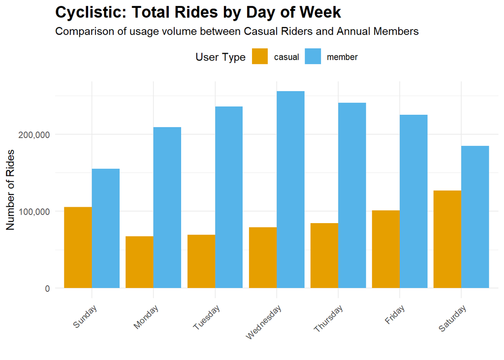

```r
# Define custom professional colors (optional, but recommended)
cyclistic_colors <- c("casual" = "#E69F00", "member" = "#56B4E9") # Orange and Blue

ggplot(data = weekly_summary, aes(x = weekday, y = number_of_rides, fill = member_casual)) +
  # geom_col creates bar charts for pre-summarized data.
  # position = "dodge" places the bars side-by-side instead of stacked.
  geom_col(position = "dodge") +

  # Adding professional labels and titles
  labs(title = "Cyclistic: Total Rides by Day of Week",
       subtitle = "Comparison of usage volume between Casual Riders and Annual Members",
       x = "", # Removing x-label because days of week are obvious
       y = "Number of Rides",
       fill = "User Type") +

  # Formatting the y-axis to have commas for thousands (e.g., 50,000)
  scale_y_continuous(labels = comma) +

  # Applying custom colors
  scale_fill_manual(values = cyclistic_colors) +

  # Using a clean, minimalist theme standard for business presentations
  theme_minimal() +

  # Slight adjustments for better readability
  theme(axis.text.x = element_text(angle = 45, hjust = 1), # Tilts text if it overlaps
        plot.title = element_text(face = "bold", size = 16),
        legend.position = "top") # Moves legend to top to save space
```

### 2: Average Ride Duration by Day and User Type

The Goal: Visualize behavior. Are they commuting (short trips) or exploring (long trips)? The Story it Tells: This is usually the most striking chart. Casual riders almost always take significantly longer trips than members, regardless of the day.

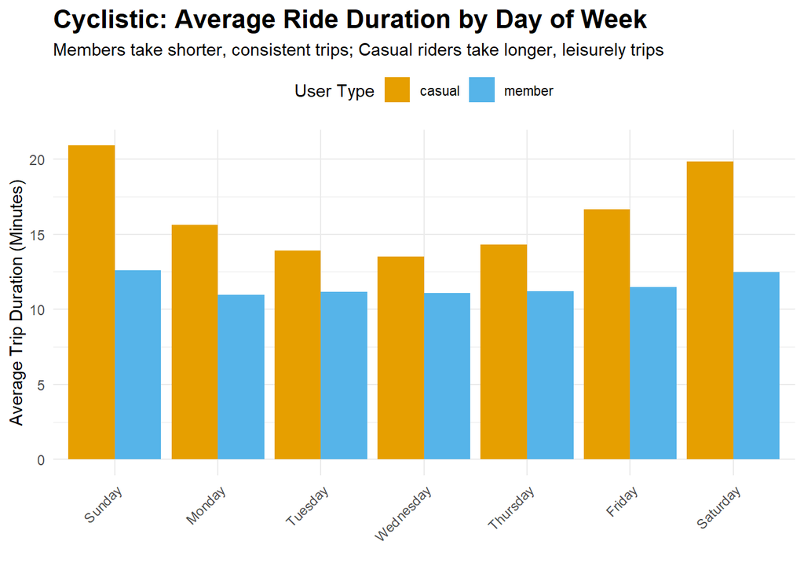

```r
ggplot(data = weekly_summary, aes(x = weekday, y = avg_ride_length_mins, fill = member_casual)) +
  geom_col(position = "dodge") +

  labs(title = "Cyclistic: Average Ride Duration by Day of Week",
       subtitle = "Members take shorter, consistent trips; Casual riders take longer, leisurely trips",
       x = "",
       y = "Average Trip Duration (Minutes)",
       fill = "User Type") +

  # No need for comma scale here as minutes usually stay under 60
  scale_fill_manual(values = cyclistic_colors) +
  theme_minimal() +
  theme(axis.text.x = element_text(angle = 45, hjust = 1),
        plot.title = element_text(face = "bold", size = 16),
        legend.position = "top")
```

## The Final Recommendation:

To convert casual riders into members, a standard ‘commuter’ membership won’t appeal to them. We need marketing that targets their desire for longer, weekend leisure rides—perhaps offering a ‘Weekend warrior’ annual pass or highlighting how a membership makes those long weekend rides cheaper.